# Прогнозирование оттока клиентов телеком-компании

### Описание проекта

Оператор связи **«Ниединогоразрыва.ком»** хочет научиться прогнозировать отток клиентов.

Если выяснится, что пользователь планирует уйти, ему будут предложены промокоды и специальные условия.

Команда оператора собрала персональные данные о некоторых клиентах, информацию об их тарифах и договорах.

**Цель:**

Классификиция клиентов на тех, кто уходит и кто остается. Удержание клиентов и минимизация убытков.

#### Описание услуг

Оператор предоставляет два основных типа услуг:

1. **Стационарную телефонную связь.** Возможно подключение телефонного аппарата к нескольким линиям одновременно.
2. **Интернет.** Подключение может быть двух типов: через телефонную линию (DSL*,* от англ. *digital subscriber line*, «цифровая абонентская линия») или оптоволоконный кабель (*Fiber optic*).

Также доступны такие услуги:

- **Интернет-безопасность:** антивирус (*DeviceProtection*) и блокировка небезопасных сайтов (*OnlineSecurity*);
- **Выделенная линия технической поддержки** (*TechSupport*);
- **Облачное хранилище файлов для резервного копирования данных** (*OnlineBackup*);
- **Стриминговое телевидение** (*StreamingTV*) и **каталог фильмов** (*StreamingMovies*).

За услуги клиенты могут платить каждый месяц или заключить договор на 1–2 года. Доступны различные способы расчёта и возможность получения электронного чека.

#### Описание данных

Данные состоят из файлов, полученных из разных источников:

- `contract_new.csv` — информация о договоре;
- `personal_new.csv` — персональные данные клиента;
- `internet_new.csv` — информация об интернет-услугах;
- `phone_new.csv` — информация об услугах телефонии.

Во всех файлах столбец `customerID` содержит код клиента.

Информация о договорах актуальна **на 1 февраля 2020**.

**Обозначения признаков:**

- `BeginDate` – дата начала пользования услугами,
- `EndDate` – дата окончания пользования услугами,
- `Type` – тип оплаты: ежемесячный, годовой и тд,
- `PaperlessBilling` – безналичный расчет,
- `PaymentMethod` – способ оплаты,
- `MonthlyCharges` – ежемесячные траты на услуги,
- `TotalCharges` – всего потрачено денег на услуги,
- `Dependents` – наличие иждивенцев,
- `SeniorCitizen` – наличие пенсионного статуса по возрасту,
- `Partner` – наличие супруга(и),
- `MultipleLines` – наличие возможности ведения параллельных линий во время звонка

#### Критерии оценки работы

Основная метрика: **AUC-ROC ⩾ 0.85**

Дополнительная метрика: Accuracy

### Предварительный обзор данных

```python
import pandas as pd

import cufflinks as cf
cf.go_offline()
import plotly.graph_objects as go

from colorama import Style, Fore
```

```python
blu = Style.BRIGHT + Fore.BLUE
ylw = Style.BRIGHT + Fore.YELLOW
grn = Style.BRIGHT + Fore.GREEN
blk = Style.BRIGHT + Fore.BLACK
res = Style.RESET_ALL
```

```python
try:
    contract = pd.read_csv('C:\\Users\\1\\Downloads\\contract_new.csv')
    personal = pd.read_csv('C:\\Users\\1\\Downloads\\personal_new.csv')
    internet = pd.read_csv('C:\\Users\\1\\Downloads\\internet_new.csv')
    phone = pd.read_csv('C:\\Users\\1\\Downloads\\phone_new.csv')
except:
    contract = pd.read_csv('/datasets/contract_new.csv')
    personal = pd.read_csv('/datasets/personal_new.csv')
    internet = pd.read_csv('/datasets/internet_new.csv')
    phone = pd.read_csv('/datasets/phone_new.csv')
```

```python
datasets = [contract, personal, internet, phone]

contract.name = 'ДАННЫЕ ДОГОВОРА'
personal.name = 'ПЕРСОНАЛЬНЫЕ ДАННЫЕ КЛИЕНТА'
internet.name = 'ИНФОРМАЦИЯ ОБ ИНТЕРНЕТ-УСЛУГАХ'
phone.name = 'ИНФОРМАЦИЯ ОБ УСЛУГАХ ТЕЛЕФОНИИ'
```

```python
def report(dataset):
    print()
    print(ylw+f'ОТЧЕТ О ДАТАСЕТЕ {dataset.name}')
    print(res)
    print(blk+'Количество уникальных пользователей в датасете :', blu+f'{dataset["customerID"].nunique()}'+res)
    print(f'Процент пользователей от датасета с данными договора : {len(dataset) / len(contract):.1%}')
    print(f'Размер датасета : {dataset.shape[0]} строк, {dataset.shape[1]} колонок')
    print('Количество пропусков :', dataset.isna().sum().sum())
    print('Количество полных дубликатов', dataset.duplicated().sum())
    print()
    print(grn+'Образец данных'+res)
    display(dataset.head())
    print()
    print(grn+'Общая информация, типы данных, пропуски')
    print(res)
    dataset.info()
    print()
    print(grn+'Доля пропусков в колонках')
    print(res)
    print(dataset.isna().mean())
    print()
    print(grn+'Описательная статистика'+res)
    display(dataset.describe())
    dataset.iplot(kind = 'hist',
                  subplots = True,
                  keys = list(dataset.drop('customerID', axis=1).columns),
                  dimensions=(990, len(dataset.columns)*150), showlegend=True,
                  title = f'Графики распределения признаков датасета {dataset.name}',
                  subplot_titles=list(dataset.drop('customerID', axis=1).columns))
    print()
    print()
```

```python
for dataset in datasets:
    report(dataset)
```

```
ОТЧЕТ О ДАТАСЕТЕ ДАННЫЕ ДОГОВОРА

Количество уникальных пользователей в датасете : 7043
Процент пользователей от датасета с данными договора : 100.0%
Размер датасета : 7043 строк, 8 колонок
Количество пропусков : 0
Количество полных дубликатов 0

Образец данных
```

|  | customerID | BeginDate | EndDate | Type | PaperlessBilling | PaymentMethod | MonthlyCharges | TotalCharges |
| --- | --- | --- | --- | --- | --- | --- | --- | --- |
| 0 | 7590-VHVEG | 2020-01-01 | No | Month-to-month | Yes | Electronic check | 29.85 | 31.04 |
| 1 | 5575-GNVDE | 2017-04-01 | No | One year | No | Mailed check | 56.95 | 2071.84 |
| 2 | 3668-QPYBK | 2019-10-01 | No | Month-to-month | Yes | Mailed check | 53.85 | 226.17 |
| 3 | 7795-CFOCW | 2016-05-01 | No | One year | No | Bank transfer (automatic) | 42.30 | 1960.6 |
| 4 | 9237-HQITU | 2019-09-01 | No | Month-to-month | Yes | Electronic check | 70.70 | 353.5 |

```
Общая информация, типы данных, пропуски

<class 'pandas.core.frame.DataFrame'>
RangeIndex: 7043 entries, 0 to 7042
Data columns (total 8 columns):
 #   Column            Non-Null Count  Dtype
---  ------            --------------  -----
 0   customerID        7043 non-null   object
 1   BeginDate         7043 non-null   object
 2   EndDate           7043 non-null   object
 3   Type              7043 non-null   object
 4   PaperlessBilling  7043 non-null   object
 5   PaymentMethod     7043 non-null   object
 6   MonthlyCharges    7043 non-null   float64
 7   TotalCharges      7043 non-null   object
dtypes: float64(1), object(7)
memory usage: 440.3+ KB

Доля пропусков в колонках

customerID          0.0
BeginDate           0.0
EndDate             0.0
Type                0.0
PaperlessBilling    0.0
PaymentMethod       0.0
MonthlyCharges      0.0
TotalCharges        0.0
dtype: float64

Описательная статистика
```

|  | MonthlyCharges |
| --- | --- |
| count | 7043.000000 |
| mean | 64.761692 |
| std | 30.090047 |
| min | 18.250000 |
| 25% | 35.500000 |
| 50% | 70.350000 |
| 75% | 89.850000 |
| max | 118.750000 |

[interactive chart not shown]

```
ОТЧЕТ О ДАТАСЕТЕ ПЕРСОНАЛЬНЫЕ ДАННЫЕ КЛИЕНТА

Количество уникальных пользователей в датасете : 7043
Процент пользователей от датасета с данными договора : 100.0%
Размер датасета : 7043 строк, 5 колонок
Количество пропусков : 0
Количество полных дубликатов 0

Образец данных
```

|  | customerID | gender | SeniorCitizen | Partner | Dependents |
| --- | --- | --- | --- | --- | --- |
| 0 | 7590-VHVEG | Female | 0 | Yes | No |
| 1 | 5575-GNVDE | Male | 0 | No | No |
| 2 | 3668-QPYBK | Male | 0 | No | No |
| 3 | 7795-CFOCW | Male | 0 | No | No |
| 4 | 9237-HQITU | Female | 0 | No | No |

```
Общая информация, типы данных, пропуски

<class 'pandas.core.frame.DataFrame'>
RangeIndex: 7043 entries, 0 to 7042
Data columns (total 5 columns):
 #   Column         Non-Null Count  Dtype
---  ------         --------------  -----
 0   customerID     7043 non-null   object
 1   gender         7043 non-null   object
 2   SeniorCitizen  7043 non-null   int64
 3   Partner        7043 non-null   object
 4   Dependents     7043 non-null   object
dtypes: int64(1), object(4)
memory usage: 275.2+ KB

Доля пропусков в колонках

customerID       0.0
gender           0.0
SeniorCitizen    0.0
Partner          0.0
Dependents       0.0
dtype: float64

Описательная статистика
```

|  | SeniorCitizen |
| --- | --- |
| count | 7043.000000 |
| mean | 0.162147 |
| std | 0.368612 |
| min | 0.000000 |
| 25% | 0.000000 |
| 50% | 0.000000 |
| 75% | 0.000000 |
| max | 1.000000 |

[interactive chart not shown]

```
ОТЧЕТ О ДАТАСЕТЕ ИНФОРМАЦИЯ ОБ ИНТЕРНЕТ-УСЛУГАХ

Количество уникальных пользователей в датасете : 5517
Процент пользователей от датасета с данными договора : 78.3%
Размер датасета : 5517 строк, 8 колонок
Количество пропусков : 0
Количество полных дубликатов 0

Образец данных
```

|  | customerID | InternetService | OnlineSecurity | OnlineBackup | DeviceProtection | TechSupport | StreamingTV | StreamingMovies |
| --- | --- | --- | --- | --- | --- | --- | --- | --- |
| 0 | 7590-VHVEG | DSL | No | Yes | No | No | No | No |
| 1 | 5575-GNVDE | DSL | Yes | No | Yes | No | No | No |
| 2 | 3668-QPYBK | DSL | Yes | Yes | No | No | No | No |
| 3 | 7795-CFOCW | DSL | Yes | No | Yes | Yes | No | No |
| 4 | 9237-HQITU | Fiber optic | No | No | No | No | No | No |

```
Общая информация, типы данных, пропуски

<class 'pandas.core.frame.DataFrame'>
RangeIndex: 5517 entries, 0 to 5516
Data columns (total 8 columns):
 #   Column            Non-Null Count  Dtype
---  ------            --------------  -----
 0   customerID        5517 non-null   object
 1   InternetService   5517 non-null   object
 2   OnlineSecurity    5517 non-null   object
 3   OnlineBackup      5517 non-null   object
 4   DeviceProtection  5517 non-null   object
 5   TechSupport       5517 non-null   object
 6   StreamingTV       5517 non-null   object
 7   StreamingMovies   5517 non-null   object
dtypes: object(8)
memory usage: 344.9+ KB

Доля пропусков в колонках

customerID          0.0
InternetService     0.0
OnlineSecurity      0.0
OnlineBackup        0.0
DeviceProtection    0.0
TechSupport         0.0
StreamingTV         0.0
StreamingMovies     0.0
dtype: float64

Описательная статистика
```

|  | customerID | InternetService | OnlineSecurity | OnlineBackup | DeviceProtection | TechSupport | StreamingTV | StreamingMovies |
| --- | --- | --- | --- | --- | --- | --- | --- | --- |
| count | 5517 | 5517 | 5517 | 5517 | 5517 | 5517 | 5517 | 5517 |
| unique | 5517 | 2 | 2 | 2 | 2 | 2 | 2 | 2 |
| top | 6859-QNXIQ | Fiber optic | No | No | No | No | No | No |
| freq | 1 | 3096 | 3498 | 3088 | 3095 | 3473 | 2810 | 2785 |

[interactive chart not shown]

```
ОТЧЕТ О ДАТАСЕТЕ ИНФОРМАЦИЯ ОБ УСЛУГАХ ТЕЛЕФОНИИ

Количество уникальных пользователей в датасете : 6361
Процент пользователей от датасета с данными договора : 90.3%
Размер датасета : 6361 строк, 2 колонок
Количество пропусков : 0
Количество полных дубликатов 0

Образец данных
```

|  | customerID | MultipleLines |
| --- | --- | --- |
| 0 | 5575-GNVDE | No |
| 1 | 3668-QPYBK | No |
| 2 | 9237-HQITU | No |
| 3 | 9305-CDSKC | Yes |
| 4 | 1452-KIOVK | Yes |

```
Общая информация, типы данных, пропуски

<class 'pandas.core.frame.DataFrame'>
RangeIndex: 6361 entries, 0 to 6360
Data columns (total 2 columns):
 #   Column         Non-Null Count  Dtype
---  ------         --------------  -----
 0   customerID     6361 non-null   object
 1   MultipleLines  6361 non-null   object
dtypes: object(2)
memory usage: 99.5+ KB

Доля пропусков в колонках

customerID       0.0
MultipleLines    0.0
dtype: float64

Описательная статистика
```

|  | customerID | MultipleLines |
| --- | --- | --- |
| count | 6361 | 6361 |
| unique | 6361 | 2 |
| top | 6859-QNXIQ | No |
| freq | 1 | 3390 |

[interactive chart not shown]

```python
print(ylw+'Число пользователей только услуги "Интернет"       : ', end='')
print(blk+f"{len(set(internet['customerID'])-set(phone['customerID']))}")

print(ylw+'Число пользователей только услуги "Телефония"      : ', end='')
print(blk+f"{len(set(phone['customerID'])-set(internet['customerID']))}")

print(ylw+'Число пользователей услуг "Интернет" и "Телефония" : ', end='')
print(blk+f"{len(set(phone['customerID'])&set(internet['customerID']))}")
```

```
Число пользователей только услуги "Интернет"       : 682
Число пользователей только услуги "Телефония"      : 1526
Число пользователей услуг "Интернет" и "Телефония" : 4835
```

```python
labels=["<b>Все клиенты<b>", "Телефония", "Интернет и телефония", "Интернет"]
parents=["", "<b>Все клиенты<b>", "<b>Все клиенты<b>", "<b>Все клиенты<b>"]
values=[7043, 1526, 4835, 682]

fig =go.Figure(go.Sunburst(labels=labels,
                           parents=parents,
                           values=values,
                           textinfo='label+value+percent parent',
                           insidetextorientation='horizontal',
                           textfont_size=14,
                           branchvalues="total")
              )
fig.update_layout(margin = dict(t=80, l=0, r=0, b=0),
                 title='Структура пользования услугами компании',
                  title_x=0.5)

fig.show()
```

[interactive chart not shown]

**Выводы по разделу:**

- исходные данные содержат информацию о **7043 пользователях**, из них **5517 пользуются услугами интернет** и **6361 пользуются услугами телефонии**.
- в исходных данных **нет пропусков и полных дубликатов**.
- в данных есть **несоответствие типов данных**.
- **отсутствие в явном виде целевого признака**.
- большинство пользователей производит оплату ежемесячно по безналичному расчету с получением электронного чека.
- наибольшее количество составляет размер оплаты ежемесячных услуг ~ 18 - 22 ден.единиц.
- по гендерному признаку количество пользователей примерно одинаковое. Пенсионеры по позрасту составляют примерно 1/5 часть. Холостых / одиноких пользователей чуть больше, чем семейных. Иждивенцев имеет примерно половина пользователей.
- среди пользователей услуги интернет предпочтение отдается подключению по оптоволоконному кабелю. БОльшая часть пользователей не пользуется услугами блокировки небезопасных сайтов, облачным хранилищем файлов, антивирусом, выделенной линией технической поддержки. Количество пользователей услуг стримингового телевидения и каталога фильмов примерно одинаковое.
- среди пользователей услуг телефонии больше пользователей, не имеющих возможности ведения параллельных линий во время звонка.

### План работы

#### Изучение задачи и обзор исходных данных заказчика:

- ознакомление с поставленной задачей, основными признаками и целевой метрикой оценки модели машинного обучения,
- обзор исходных файлов - основная информация, типы данных, описательная статистика.

#### Предобработка и исследовательский анализ данных:

- объединение данных, обработка пропусков, дубликатов, аномалий,
- приведение в соответствие типов данных,
- инжиниринг признаков, создание целевого признака, удаление неинформативных и проблемных с точки зрения утечки данных,
- исследование баланса классов, сравнение данных в зависимости от класса,
- визуализация данных,
- исследование корреляций признаков.

#### Подготовка данных для машинного обучения:

- разделение данных на обучающую и тестовую выборки.

#### Машинное обучение:

- обучение и сравнение нескольких алгоритмов классификации методом кросс-валидации, выбор лучшей модели по заданной метрике.

#### Проверка лучшей модели:

- тестирование на тестовой выборке,
- сравнение с константной моделью.

#### Выводы по решению задачи.

```python
import numpy as np
import phik

from sklearn.model_selection import (
    train_test_split,
    GridSearchCV
)

from sklearn.preprocessing import OrdinalEncoder
from sklearn.utils.class_weight import compute_class_weight
from sklearn.feature_selection import mutual_info_classif
from sklearn.model_selection import RepeatedStratifiedKFold
from sklearn.metrics import (
    accuracy_score,
    confusion_matrix,
    ConfusionMatrixDisplay,
    roc_auc_score
)

from sklearn.ensemble import RandomForestClassifier
from catboost import CatBoostClassifier
from lightgbm import LGBMClassifier
from sklearn.dummy import DummyClassifier

from statsmodels.tsa.seasonal import seasonal_decompose

import plotly.express as px
from plotly.subplots import make_subplots
from plotly.offline import init_notebook_mode
init_notebook_mode(connected=True)

import warnings
warnings.simplefilter(action='ignore')
```

```python
RANDOM_STATE = 50623
```

### Предобработка и исследовательский анализ данных

Объединим данные всех файлов по ID клиента и рассмотрим полученную таблицу.

```python
full = contract.merge(personal, on='customerID', how='outer'
              ).merge(internet, on='customerID', how='outer'
              ).merge(phone, on='customerID', how='outer')
```

```python
full.isna().sum()
```

```
customerID             0
BeginDate              0
EndDate                0
Type                   0
PaperlessBilling       0
PaymentMethod          0
MonthlyCharges         0
TotalCharges           0
gender                 0
SeniorCitizen          0
Partner                0
Dependents             0
InternetService     1526
OnlineSecurity      1526
OnlineBackup        1526
DeviceProtection    1526
TechSupport         1526
StreamingTV         1526
StreamingMovies     1526
MultipleLines        682
dtype: int64
```

```python
full.head(10).T
```

|  | 0 | 1 | 2 | 3 | 4 | 5 | 6 | 7 | 8 | 9 |
| --- | --- | --- | --- | --- | --- | --- | --- | --- | --- | --- |
| customerID | 7590-VHVEG | 5575-GNVDE | 3668-QPYBK | 7795-CFOCW | 9237-HQITU | 9305-CDSKC | 1452-KIOVK | 6713-OKOMC | 7892-POOKP | 6388-TABGU |
| BeginDate | 2020-01-01 | 2017-04-01 | 2019-10-01 | 2016-05-01 | 2019-09-01 | 2019-03-01 | 2018-04-01 | 2019-04-01 | 2017-07-01 | 2014-12-01 |
| EndDate | No | No | No | No | No | No | No | No | No | 2017-05-01 |
| Type | Month-to-month | One year | Month-to-month | One year | Month-to-month | Month-to-month | Month-to-month | Month-to-month | Month-to-month | One year |
| PaperlessBilling | Yes | No | Yes | No | Yes | Yes | Yes | No | Yes | No |
| PaymentMethod | Electronic check | Mailed check | Mailed check | Bank transfer (automatic) | Electronic check | Electronic check | Credit card (automatic) | Mailed check | Electronic check | Bank transfer (automatic) |
| MonthlyCharges | 29.85 | 56.95 | 53.85 | 42.3 | 70.7 | 99.65 | 89.1 | 29.75 | 104.8 | 56.15 |
| TotalCharges | 31.04 | 2071.84 | 226.17 | 1960.6 | 353.5 | 1150.96 | 2058.21 | 300.48 | 3573.68 | 1628.35 |
| gender | Female | Male | Male | Male | Female | Female | Male | Female | Female | Male |
| SeniorCitizen | 0 | 0 | 0 | 0 | 0 | 0 | 0 | 0 | 0 | 0 |
| Partner | Yes | No | No | No | No | No | No | No | Yes | No |
| Dependents | No | No | No | No | No | No | Yes | No | No | Yes |
| InternetService | DSL | DSL | DSL | DSL | Fiber optic | Fiber optic | Fiber optic | DSL | Fiber optic | DSL |
| OnlineSecurity | No | Yes | Yes | Yes | No | No | No | Yes | No | Yes |
| OnlineBackup | Yes | No | Yes | No | No | No | Yes | No | No | Yes |
| DeviceProtection | No | Yes | No | Yes | No | Yes | No | No | Yes | No |
| TechSupport | No | No | No | Yes | No | No | No | No | Yes | No |
| StreamingTV | No | No | No | No | No | Yes | Yes | No | Yes | No |
| StreamingMovies | No | No | No | No | No | Yes | No | No | Yes | No |
| MultipleLines | NaN | No | No | NaN | No | Yes | Yes | NaN | Yes | No |

```python
full.tail(10).T
```

|  | 7033 | 7034 | 7035 | 7036 | 7037 | 7038 | 7039 | 7040 | 7041 | 7042 |
| --- | --- | --- | --- | --- | --- | --- | --- | --- | --- | --- |
| customerID | 9767-FFLEM | 0639-TSIQW | 8456-QDAVC | 7750-EYXWZ | 2569-WGERO | 6840-RESVB | 2234-XADUH | 4801-JZAZL | 8361-LTMKD | 3186-AJIEK |
| BeginDate | 2016-12-01 | 2014-03-01 | 2018-07-01 | 2019-02-01 | 2014-02-01 | 2018-02-01 | 2014-02-01 | 2019-03-01 | 2019-07-01 | 2014-08-01 |
| EndDate | No | 2015-11-01 | No | No | No | No | No | No | No | No |
| Type | Month-to-month | Month-to-month | Month-to-month | One year | Two year | One year | One year | Month-to-month | Month-to-month | Two year |
| PaperlessBilling | Yes | Yes | Yes | No | Yes | Yes | Yes | Yes | Yes | Yes |
| PaymentMethod | Credit card (automatic) | Credit card (automatic) | Bank transfer (automatic) | Electronic check | Bank transfer (automatic) | Mailed check | Credit card (automatic) | Electronic check | Mailed check | Bank transfer (automatic) |
| MonthlyCharges | 69.5 | 102.95 | 78.7 | 60.65 | 21.15 | 84.8 | 103.2 | 29.6 | 74.4 | 105.65 |
| TotalCharges | 2693.82 | 2059.0 | 1585.02 | 727.8 | 1553.26 | 2035.2 | 7430.4 | 325.6 | 520.8 | 7251.82 |
| gender | Male | Female | Male | Female | Female | Male | Female | Female | Male | Male |
| SeniorCitizen | 0 | 0 | 0 | 0 | 0 | 0 | 0 | 0 | 1 | 0 |
| Partner | No | No | No | No | No | Yes | Yes | Yes | Yes | No |
| Dependents | No | No | No | No | No | Yes | Yes | Yes | No | No |
| InternetService | Fiber optic | Fiber optic | Fiber optic | DSL | NaN | DSL | Fiber optic | DSL | Fiber optic | Fiber optic |
| OnlineSecurity | No | Yes | No | No | NaN | Yes | No | Yes | No | Yes |
| OnlineBackup | No | Yes | No | Yes | NaN | No | Yes | No | No | No |
| DeviceProtection | No | Yes | No | Yes | NaN | Yes | Yes | No | No | Yes |
| TechSupport | No | No | No | Yes | NaN | Yes | No | No | No | Yes |
| StreamingTV | No | Yes | Yes | Yes | NaN | Yes | Yes | No | No | Yes |
| StreamingMovies | No | No | No | Yes | NaN | Yes | Yes | No | No | Yes |
| MultipleLines | No | Yes | No | NaN | No | Yes | Yes | NaN | Yes | No |

```python
print('Количество полных дубликатов :', full.duplicated().sum())
```

```
Количество полных дубликатов : 0
```

```python
full.info()
```

```
<class 'pandas.core.frame.DataFrame'>
Int64Index: 7043 entries, 0 to 7042
Data columns (total 20 columns):
 #   Column            Non-Null Count  Dtype
---  ------            --------------  -----
 0   customerID        7043 non-null   object
 1   BeginDate         7043 non-null   object
 2   EndDate           7043 non-null   object
 3   Type              7043 non-null   object
 4   PaperlessBilling  7043 non-null   object
 5   PaymentMethod     7043 non-null   object
 6   MonthlyCharges    7043 non-null   float64
 7   TotalCharges      7043 non-null   object
 8   gender            7043 non-null   object
 9   SeniorCitizen     7043 non-null   int64
 10  Partner           7043 non-null   object
 11  Dependents        7043 non-null   object
 12  InternetService   5517 non-null   object
 13  OnlineSecurity    5517 non-null   object
 14  OnlineBackup      5517 non-null   object
 15  DeviceProtection  5517 non-null   object
 16  TechSupport       5517 non-null   object
 17  StreamingTV       5517 non-null   object
 18  StreamingMovies   5517 non-null   object
 19  MultipleLines     6361 non-null   object
dtypes: float64(1), int64(1), object(18)
memory usage: 1.1+ MB
```

Пропуски в колонках после объединения таблиц связаны с отсутствием подключения пользователя к той или иной услуге, поэтому их можно заполнить значением 'No'.

```python
full = full.fillna('No')
```

Так как даты начала и окончания контракта имею тип данных `'object'`, и, по крайней мере, в колонке даты окончания контракта помимо строковых значений даты есть строковые значения, означающие, что на дату выгрузки данных контракт действителен, воспользуемся параметром `errors ='coerce'` метода `pandas to_datetime` для преобразования типа данных.

```python
for column in ['BeginDate', 'EndDate']:
    full[column] = pd.to_datetime(full[column], errors ='coerce')
    print(f'Количество пропусков в колонке "{column}" :', full[column].isna().sum())
    print('Тип данных признака :', full[column].dtype)
    print()
```

```
Количество пропусков в колонке "BeginDate" : 0
Тип данных признака : datetime64[ns]

Количество пропусков в колонке "EndDate" : 5942
Тип данных признака : datetime64[ns]
```

```python
contract.query('EndDate == "2020-02-01"').customerID.count()
```

```
0
```

В исходных данных нет клиентов, для которых даты выгрузки и завершения контракта совпадают. Пропуски в датах окончания контракта заменим датой выгрузки данных.

```python
full['EndDate'] = full['EndDate'].fillna('2020-02-01').astype('datetime64[ns]')
```

```python
full[['BeginDate', 'EndDate']].describe()
```

|  | BeginDate | EndDate |
| --- | --- | --- |
| count | 7043 | 7043 |
| unique | 77 | 67 |
| top | 2014-02-01 00:00:00 | 2020-02-01 00:00:00 |
| freq | 366 | 5942 |
| first | 2013-10-01 00:00:00 | 2014-06-01 00:00:00 |
| last | 2020-02-01 00:00:00 | 2020-02-01 00:00:00 |

Тип данных `'object'` колонки `'TotalCharges'` также вероятнее всего связан с наличием строковых значений.

```python
full['TotalCharges'] = pd.to_numeric(full['TotalCharges'], errors='coerce')

print('Количество пропусков в колонке :', full['TotalCharges'].isna().sum())
```

```
Количество пропусков в колонке : 11
```

```python
full.query('TotalCharges.isna()').T
```

|  | 488 | 753 | 936 | 1082 | 1340 | 3331 | 3826 | 4380 | 5218 | 6670 | 6754 |
| --- | --- | --- | --- | --- | --- | --- | --- | --- | --- | --- | --- |
| customerID | 4472-LVYGI | 3115-CZMZD | 5709-LVOEQ | 4367-NUYAO | 1371-DWPAZ | 7644-OMVMY | 3213-VVOLG | 2520-SGTTA | 2923-ARZLG | 4075-WKNIU | 2775-SEFEE |
| BeginDate | 2020-02-01 00:00:00 | 2020-02-01 00:00:00 | 2020-02-01 00:00:00 | 2020-02-01 00:00:00 | 2020-02-01 00:00:00 | 2020-02-01 00:00:00 | 2020-02-01 00:00:00 | 2020-02-01 00:00:00 | 2020-02-01 00:00:00 | 2020-02-01 00:00:00 | 2020-02-01 00:00:00 |
| EndDate | 2020-02-01 00:00:00 | 2020-02-01 00:00:00 | 2020-02-01 00:00:00 | 2020-02-01 00:00:00 | 2020-02-01 00:00:00 | 2020-02-01 00:00:00 | 2020-02-01 00:00:00 | 2020-02-01 00:00:00 | 2020-02-01 00:00:00 | 2020-02-01 00:00:00 | 2020-02-01 00:00:00 |
| Type | Two year | Two year | Two year | Two year | Two year | Two year | Two year | Two year | One year | Two year | Two year |
| PaperlessBilling | Yes | No | No | No | No | No | No | No | Yes | No | Yes |
| PaymentMethod | Bank transfer (automatic) | Mailed check | Mailed check | Mailed check | Credit card (automatic) | Mailed check | Mailed check | Mailed check | Mailed check | Mailed check | Bank transfer (automatic) |
| MonthlyCharges | 52.55 | 20.25 | 80.85 | 25.75 | 56.05 | 19.85 | 25.35 | 20.0 | 19.7 | 73.35 | 61.9 |
| TotalCharges | NaN | NaN | NaN | NaN | NaN | NaN | NaN | NaN | NaN | NaN | NaN |
| gender | Female | Male | Female | Male | Female | Male | Male | Female | Male | Female | Male |
| SeniorCitizen | 0 | 0 | 0 | 0 | 0 | 0 | 0 | 0 | 0 | 0 | 0 |
| Partner | Yes | No | Yes | Yes | Yes | Yes | Yes | Yes | Yes | Yes | No |
| Dependents | Yes | Yes | Yes | Yes | Yes | Yes | Yes | Yes | Yes | Yes | Yes |
| InternetService | DSL | No | DSL | No | DSL | No | No | No | No | DSL | DSL |
| OnlineSecurity | Yes | No | Yes | No | Yes | No | No | No | No | No | Yes |
| OnlineBackup | No | No | Yes | No | Yes | No | No | No | No | Yes | Yes |
| DeviceProtection | Yes | No | Yes | No | Yes | No | No | No | No | Yes | No |
| TechSupport | Yes | No | No | No | Yes | No | No | No | No | Yes | Yes |
| StreamingTV | Yes | No | Yes | No | Yes | No | No | No | No | Yes | No |
| StreamingMovies | No | No | Yes | No | No | No | No | No | No | No | No |
| MultipleLines | No | No | No | Yes | No | No | Yes | No | No | Yes | Yes |

Можно заметить, что данные в колонке общих расходов отсутствуют у клиентов, заключивших контракт на услуги в день выгрузки данных. В остальных колонках у этих клиентов пропусков нет, поэтому пропуски можно заполнить соответствующими значениями месячных расходов.

```python
full.loc[full['TotalCharges'].isna(), 'TotalCharges'] = full.loc[full['TotalCharges'].isna(), 'MonthlyCharges']
```

Так как даты начала и окончания договора не могут быть использованы для обучения моделей из-за утечки целевого признака, создадим новый признак - продолжительность клиентского стажа в днях, а так же целевой признак: клиент ушел `(Класс=1)` или нет `(Класс=0)`.

```python
full['Tenure'] = (full['EndDate'] - full['BeginDate']).dt.days
```

```python
full['Left'] = np.where(full['EndDate'] == '2020-02-01', 0, 1)
```

```python
full['Left'].value_counts(normalize=1)
```

```
0    0.843675
1    0.156325
Name: Left, dtype: float64
```

**Классы не сбалансированы:** ушедших клиентов **`(Класс=1)`~ 16%,** оставшихся **`(Класс=0)`~ 84%.**

Проверим данные:

```python
full.info()
```

```
<class 'pandas.core.frame.DataFrame'>
Int64Index: 7043 entries, 0 to 7042
Data columns (total 22 columns):
 #   Column            Non-Null Count  Dtype
---  ------            --------------  -----
 0   customerID        7043 non-null   object
 1   BeginDate         7043 non-null   datetime64[ns]
 2   EndDate           7043 non-null   datetime64[ns]
 3   Type              7043 non-null   object
 4   PaperlessBilling  7043 non-null   object
 5   PaymentMethod     7043 non-null   object
 6   MonthlyCharges    7043 non-null   float64
 7   TotalCharges      7043 non-null   float64
 8   gender            7043 non-null   object
 9   SeniorCitizen     7043 non-null   int64
 10  Partner           7043 non-null   object
 11  Dependents        7043 non-null   object
 12  InternetService   7043 non-null   object
 13  OnlineSecurity    7043 non-null   object
 14  OnlineBackup      7043 non-null   object
 15  DeviceProtection  7043 non-null   object
 16  TechSupport       7043 non-null   object
 17  StreamingTV       7043 non-null   object
 18  StreamingMovies   7043 non-null   object
 19  MultipleLines     7043 non-null   object
 20  Tenure            7043 non-null   int64
 21  Left              7043 non-null   int32
dtypes: datetime64[ns](2), float64(2), int32(1), int64(2), object(15)
memory usage: 1.2+ MB
```

С учетом предобработки и добавления новых признаков: в данных пропуски отсутствуют, типы данных соответствуют, полных дубликатов нет.

Сравним признаки в данных по целевому признаку.

В список категориальных признаков для визуализации добавим также признак `'SeniorCitizen'`.

```python
columns_list = ['Type', 'PaperlessBilling', 'PaymentMethod', 'gender',
                'SeniorCitizen', 'Partner', 'Dependents', 'InternetService',
                'OnlineSecurity', 'OnlineBackup', 'DeviceProtection',
                'TechSupport', 'StreamingTV', 'StreamingMovies', 'MultipleLines']


fig = make_subplots(rows=len(columns_list), cols=2,
                    specs=[[{'type':'domain'}] *2] *len(columns_list),
                    vertical_spacing=0.02,
                    )
for i, column in enumerate(columns_list):

    fig.add_trace(go.Pie(labels=full.query('Left==0')[column].value_counts().index,
                         values=full.query('Left==0')[column].value_counts().values,
                         name=f'Остались. Признак "{column}"',
                         showlegend=False,
                         title=f'<b>Клиент остался. Признак "{column}"<br> <br></b>'),
                  i+1, 1)

    fig.add_trace(go.Pie(labels=full.query('Left==1')[column].value_counts().index,
                         values=full.query('Left==1')[column].value_counts().values,
                         name=f'Ушли. Признак "{column}"',
                         showlegend=False,
                         title=f'<b>Клиент ушел. Признак "{column}"<br> <br></b>'),
                  i+1, 2)

fig.update_traces(textinfo='label+percent',
                  insidetextorientation='horizontal',
                  textfont_size=10)

fig.update_layout(title='Распределение клиентов по категориальным признакам',
                  title_x=0.5, height=300 *len(columns_list)
                  )

fig
```

[interactive chart not shown]

Если сравнивать в процентном соотношении, среди пользователей дополнительных услуг, таких как хранилище файлов, антивирус, стриминговое телевидение, каталог фильмов, ведение параллельных линий во время звонка, количество ушедших примерно но 20% больше оставшихся. Аналогично с семейными клиентами.

```python
def plot_hist(column):

    fig = px.histogram(full, x=column,
                       nbins=100, color='Left',
                       color_discrete_map={
                       1:"magenta",
                       0:"lightslategrey"},
                       histnorm="probability density",
                       marginal="box", barmode="overlay"
                      )

    fig.update_layout(title=f'График распределения признака "{column}"',
                      title_x=0.5,
                      margin=dict(t=50, l=0, r=0, b=0),
                      bargap=0.1
                     )

    fig.update_traces(row=2, boxmean=True)

    fig.show()
```

```python
plot_hist('MonthlyCharges')
```

[interactive chart not shown]

```python
plot_hist('TotalCharges')
```

[interactive chart not shown]

Исходя из характера распределения ежемесячных и годовых расходов, можно сделать вывод, что уходят те клиенты, которые больше платят за услуги.

```python
plot_hist('Tenure')
```

[interactive chart not shown]

Что касается клиентского стажа, то среди оставшихся выделяются новички и суперлояльные клиенты, стаж которых составляет порядка 6 лет. Основная масса уходящих клентов имеет стаж порядка 1,5 - 3,5 лет.

```python
users_come = full[['BeginDate', 'customerID']].set_index('BeginDate').resample('1M').count()
decomposed_come = seasonal_decompose(users_come)

users_left = full[['EndDate', 'Left']].set_index('EndDate').resample('1M').sum()
decomposed_left = seasonal_decompose(users_left)

come = [decomposed_come.trend, decomposed_come.seasonal]
left = [decomposed_left.trend, decomposed_left.seasonal]
names = ['тренд', 'сезонность']
```

```python
fig = make_subplots(rows=2, cols=1,
                    shared_xaxes=True, vertical_spacing=0.05,
                    subplot_titles=['тренд','сезонность'])

for i, (component, name) in enumerate(zip(come, names)):

    fig.add_trace(go.Scatter(name=name, x=component.index,
                             y=component.values,
                             marker_color='limegreen',
                             legendgroup='приток',
                             legendgrouptitle_text='приток',
                             showlegend=True),
                  i+1, 1)

fig.update_traces(row=2, fill='tonexty')

for i, (component, name) in enumerate(zip(left, names)):

    fig.add_trace(go.Scatter(name=name, x=component.index,
                             y=component.values,
                             marker_color='magenta',
                             legendgroup='отток',
                             legendgrouptitle_text='отток',
                             showlegend=True),
                  i+1, 1)


fig.update_layout(title="Приток и отток клиентов: тренд и сезонность",
                  title_x=0.5, margin=dict(t=50, l=0, r=0, b=0))

fig.update_annotations(font_size=12)

fig.show()
```

[interactive chart not shown]

Рассмотрим корреляции между признаками в данных.

```python
interval_cols = ['MonthlyCharges', 'TotalCharges', 'Tenure']

phik_corr = full.drop('customerID', axis=1).phik_matrix(interval_cols=interval_cols).round(2)
```

```python
fig = px.imshow(phik_corr,
                height=760,
                text_auto=True)

fig.update_layout(title_text='Фи-корреляции в данных',
                  title_x=0.5, xaxis_tickangle=-90,
                  coloraxis_colorbar=dict(
                      thickness=12,
                      len=0.3)
                 )
fig
```

[interactive chart not shown]

Самые высокие корреляции наблюдаются между следующими признаками: стаж и дата начала контракта, стаж и общие расходы клиента на оплату услуг, что вполне логично, чем больше стаж, тем больше общие расходы; месячные расходы и доп.услуги; общие расходы и доп.услуги; доп.услуги между собой.

Корреляции пола клиента со всеми остальными признаками почти равны нулю. Его можем удалить.

```python
significance_corr = full.drop('customerID', axis=1).significance_matrix(interval_cols=interval_cols).round(1)
```

```python
fig = px.imshow(significance_corr,
                height=800,
                text_auto=True)

fig.update_layout(title_text='Значимость коэффициентов Фи-корреляции в данных',
                  title_x=0.5, xaxis_tickangle=-90,
                  coloraxis_colorbar=dict(
                      thickness=12,
                      len=0.3)
                 )

fig
```

[interactive chart not shown]

**Выводы по разделу:**

- обработаны пропуски в данных, возникших после объединения исходных таблиц. Типы данных приведены в соответствие.
- сформирован целевой признак, признак, отвечающий за длительность контракта клиента (клиентский стаж).
- определены признаки, которые в дальнейшем не будут использованы для обучения моделей.
- в данных наблюдается дисбаланс классов **`(Класс=1)`~ 16%, `(Класс=0)`~ 84%**.

### Подготовка данных для машинного обучения

Выделим признаки и целевой признак в данных.

```python
X = full.drop(['customerID', 'BeginDate', 'EndDate', 'gender','Left'], axis=1)
y = full['Left']

print('Размер признаков         :', X.shape)
print('Размер целевого признака :', y.shape)
```

```
Размер признаков         : (7043, 17)
Размер целевого признака : (7043,)
```

```python
categorical = list(X.select_dtypes(include='O').columns)
```

```python
def split(X, y):

    features_train, features_test, target_train, target_test = train_test_split(
                                                                       X, y,
                                                                       test_size=0.25,
                                                                       stratify=y,
                                                                       random_state=RANDOM_STATE)

    print(f'Размер обучающей выборки          : {features_train.shape}')
    print(f'Размер целевого признака          : {target_train.shape}')
    print()
    print(f'Размер тестовой выборки           : {features_test.shape}')
    print(f'Размер целевого признака          : {target_test.shape}')

    return features_train, features_test, target_train, target_test
```

**Выводы по разделу:**

- разделены целевой и остальные признаки.
- подготовлена функция сплитования данных на обучающую и тестовую выборку в соотношении 3 : 1.

### Машинное обучение

Рассмотрим алгоритмы градиентного бустинга **LightGBM** и **CatBoost**, а также более простой алгоритм **RandomForestClassifier.**

Для алгоритма случайного леса используем технику порядкого кодирования категориальных признаков Ordinal Encoding.

Алгоритмы CatBoost и LightGBM работают с категориальными признаками напрямую.

Масштабирование признаков для алгоритмов, основанных на деревьях не требуется.

```python
encoder = OrdinalEncoder()
```

```python
X_oe = X.copy()

X_oe[categorical] = encoder.fit_transform(X_oe[categorical])
```

```python
X_train_oe, X_test_oe, y_train_oe, y_test_oe = split(X_oe, y)
```

```
Размер обучающей выборки          : (5282, 17)
Размер целевого признака          : (5282,)

Размер тестовой выборки           : (1761, 17)
Размер целевого признака          : (1761,)
```

```python
X_oe.info()
```

```
<class 'pandas.core.frame.DataFrame'>
Int64Index: 7043 entries, 0 to 7042
Data columns (total 17 columns):
 #   Column            Non-Null Count  Dtype
---  ------            --------------  -----
 0   Type              7043 non-null   float64
 1   PaperlessBilling  7043 non-null   float64
 2   PaymentMethod     7043 non-null   float64
 3   MonthlyCharges    7043 non-null   float64
 4   TotalCharges      7043 non-null   float64
 5   SeniorCitizen     7043 non-null   int64
 6   Partner           7043 non-null   float64
 7   Dependents        7043 non-null   float64
 8   InternetService   7043 non-null   float64
 9   OnlineSecurity    7043 non-null   float64
 10  OnlineBackup      7043 non-null   float64
 11  DeviceProtection  7043 non-null   float64
 12  TechSupport       7043 non-null   float64
 13  StreamingTV       7043 non-null   float64
 14  StreamingMovies   7043 non-null   float64
 15  MultipleLines     7043 non-null   float64
 16  Tenure            7043 non-null   int64
dtypes: float64(15), int64(2)
memory usage: 990.4 KB
```

Mutual information — это метод, который может фиксировать нелинейные отношения между входными объектами и целевой переменной. Взаимная информация измеряет количество информации, которую функция предоставляет о целевой переменной. Он подходит для захвата любого типа отношений, включая нелинейные и немонотонные отношения.

```python
feature_scores = mutual_info_classif(X_train_oe, y_train_oe, random_state=RANDOM_STATE)
```

```python
pd.DataFrame({'Feature': X_train_oe.columns, 'Importance': feature_scores}
            ).sort_values(by='Importance', ascending=False)
```

|  | Feature | Importance |
| --- | --- | --- |
| 16 | Tenure | 0.240422 |
| 4 | TotalCharges | 0.043559 |
| 15 | MultipleLines | 0.020914 |
| 6 | Partner | 0.020134 |
| 13 | StreamingTV | 0.014407 |
| 0 | Type | 0.013993 |
| 9 | OnlineSecurity | 0.011141 |
| 3 | MonthlyCharges | 0.010553 |
| 8 | InternetService | 0.009170 |
| 2 | PaymentMethod | 0.007403 |
| 5 | SeniorCitizen | 0.006000 |
| 11 | DeviceProtection | 0.005140 |
| 10 | OnlineBackup | 0.004143 |
| 14 | StreamingMovies | 0.003099 |
| 12 | TechSupport | 0.002836 |
| 7 | Dependents | 0.000000 |
| 1 | PaperlessBilling | 0.000000 |

#### Cлучайный лес

```python
cv = RepeatedStratifiedKFold(n_splits=3, n_repeats=3, random_state=RANDOM_STATE)
```

```python
grid = {
    'n_estimators' : range(60, 73, 3),
    'max_depth': range(10, 15, 2),
    'min_samples_leaf': range(4, 9, 2)
    }
```

```python
%%time

rfc_cv = GridSearchCV(estimator = RandomForestClassifier(random_state=RANDOM_STATE,
                                                         class_weight='balanced'),
                      param_grid = grid,
                      scoring='roc_auc',
                      n_jobs=-1,
                      verbose=True,
                      cv = cv)

rfc_cv.fit(X_train_oe, y_train_oe)


print(blk+'Лучшая модель RandomForestClassifier :', grn+f'{rfc_cv.best_estimator_}'+res)
print(blk+'Лучшее значение метрики AUC-ROC      :', grn+f'{rfc_cv.best_score_}'+res)
print()
```

```
Fitting 9 folds for each of 45 candidates, totalling 405 fits
Лучшая модель RandomForestClassifier : RandomForestClassifier(class_weight='balanced', max_depth=10,
                       min_samples_leaf=6, n_estimators=66, random_state=50623)
Лучшее значение метрики AUC-ROC      : 0.82100318201575

CPU times: total: 3min 21s
Wall time: 3min 28s
```

#### Градиентный бустинг CatBoost

```python
X_cat = X.copy()

X_cat[categorical] = X[categorical].astype('category')
```

```python
X_train_cat, X_test_cat, y_train_cat, y_test_cat = split(X_cat, y)
```

```
Размер обучающей выборки          : (5282, 17)
Размер целевого признака          : (5282,)

Размер тестовой выборки           : (1761, 17)
Размер целевого признака          : (1761,)
```

```python
classes = y_train_cat.unique()

weights = compute_class_weight(class_weight='balanced', classes=classes, y=y_train_cat)
class_weights = dict(zip(classes, weights))
```

```python
grid = {
    'iterations': [1900, 2000],
    'learning_rate': [0.07, 0.08]
    }
```

```python
%%time

cb_cv = GridSearchCV(estimator = CatBoostClassifier(cat_features=categorical,
                                                    verbose=False,
                                                    class_weights=class_weights,
                                                    random_state=RANDOM_STATE),
                     param_grid = grid,
                     scoring='roc_auc',
                     n_jobs=-1,
                     cv = cv)

cb_cv.fit(X_train_cat, y_train_cat)


print(blk+'Лучшая модель CatBoostClassifier :', ylw+f'{cb_cv.best_params_}'+res)
print(blk+'Лучшее значение метрики AUC-ROC  :', ylw+f'{cb_cv.best_score_}'+res)
print()
```

```
Лучшая модель CatBoostClassifier : {'iterations': 1900, 'learning_rate': 0.08}
Лучшее значение метрики AUC-ROC  : 0.8930317513816264

CPU times: total: 57min 49s
Wall time: 30min 28s
```

#### Градиентный бустинг LightGBM

```python
grid = {
    'max_depth': range(2, 7, 2),
    'n_estimators': range(1900, 1921, 10)
    }
```

```python
%%time

lgb_cv = GridSearchCV(estimator = LGBMClassifier(is_unbalance=True,
                                                 objective='binary',
                                                 random_state=RANDOM_STATE),
                      param_grid = grid,
                      scoring='roc_auc',
                      n_jobs=-1,
                      verbose=True,
                      cv = cv)

lgb_cv.fit(X_train_cat, y_train_cat)


print(blk+'Лучшая модель LGBMClassifier    :', blu+f'{lgb_cv.best_estimator_}'+res)
print(blk+'Лучшее значение метрики AUC-ROC :', blu+f'{lgb_cv.best_score_}'+res)
print()
```

```
Fitting 9 folds for each of 9 candidates, totalling 81 fits
Лучшая модель LGBMClassifier    : LGBMClassifier(is_unbalance=True, max_depth=2, n_estimators=1910,
               objective='binary', random_state=50623)
Лучшее значение метрики AUC-ROC : 0.8815114116978946

CPU times: total: 8min 29s
Wall time: 2min 58s
```

#### Результаты моделей

```python
pd.DataFrame(

{'model'       : ['RandomForest Classifier', 'CatBoost Classifier', 'LGBM Classifier'],

 'AUC-ROC'     : [rfc_cv.best_score_, cb_cv.best_score_, lgb_cv.best_score_]
                                                      }).set_index('model'
                                                       ).style.highlight_max(color='lightgreen'
                                                       ).highlight_min(color='pink')
```

| model | AUC-ROC |
| --- | --- |
| RandomForest Classifier | 0.821003 |
| CatBoost Classifier | 0.893032 |
| LGBM Classifier | 0.881511 |

Лучшее значение метрики **AUC-ROC** показала модель **CatBoost Classifier** с параметрами `'iterations': 1900, 'learning_rate': 0.08`.

### Проверка качества лучшей модели

Проверим модель на тестовой выборке.

```python
predictions = cb_cv.best_estimator_.predict(X_test_cat)
proba_one = cb_cv.best_estimator_.predict_proba(X_test_cat)[:, 1]

cb_test_auc = roc_auc_score(y_test_cat, proba_one).round(3)
cb_test_acc = accuracy_score(y_test_cat, predictions).round(3)


print('AUC-ROC лучшей модели на тестовой выборке :', cb_test_auc)
print('Accuracy модели на тестовой выборке       :', cb_test_acc)
```

```
AUC-ROC лучшей модели на тестовой выборке : 0.917
Accuracy модели на тестовой выборке       : 0.91
```

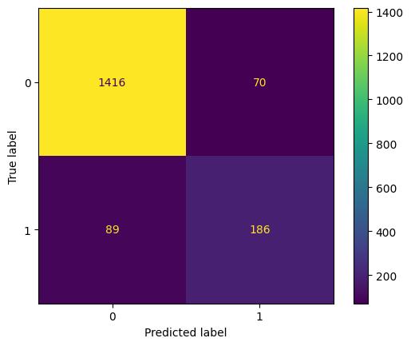

```python
ConfusionMatrixDisplay(confusion_matrix(y_test_cat, predictions)).plot();
```

```python
confusion_matrix(y_test_cat, predictions, normalize='pred')
```

```
array([[0.94086379, 0.2734375 ],
       [0.05913621, 0.7265625 ]])
```

Модель склонна давать ложно-отрицательные предсказания чуть в большей степени, чем ложно-положительные. Из предсказанного моделью оттока, 73% клиентов в действительности уйдут, 27% в действительности останутся. Из тех клиентов, которые по прогнозу модели должны остаться, в действительности останутся 94%, а 6% в действительности уйдут.

```python
importances = pd.DataFrame(data={
        'attribute': X_train_cat.columns,
        'importance': cb_cv.best_estimator_.feature_importances_.round(1)
        }).sort_values(by='importance',
                       ascending=True)

fig = px.bar(importances, orientation='h',
             y=importances['attribute'],
             x=importances['importance'],
             color=importances['importance'],
             color_continuous_scale='ylorrd',
             text=importances['importance'],
             title='Важность признаков модели',
             )

fig.update_traces(textfont_size=12, textangle=0,
                  textposition='outside'
                 )

fig.update_layout(title_x=0.5,
                  coloraxis_colorbar_thickness=12,
                  margin=dict(t=50, l=0, r=0, b=0))

fig
```

[interactive chart not shown]

Самый важный для модели признак - клиентский стаж, далее с большим отрывом следуют ежемесячные и годовые расходы, тип и способ оплаты.

#### Сравнение с Dummy-моделью

Для сравнения результатов лучшей модели используем классификатор Dummy Classifier, рассчитаем точность для этой модели со стратегией предсказания наиболее частой метки класса в обучающих данных.

```python
dummy = DummyClassifier(strategy='most_frequent')
dummy.fit(X_train_cat, y_train_cat)

dummy_predictions = dummy.predict(X_test_cat)
dummy_proba_one = dummy.predict_proba(X_test_cat)[:, 1]

dummy_auc = roc_auc_score(y_test_cat, dummy_proba_one).round(3)
dummy_acc = accuracy_score(y_test_cat, dummy_predictions).round(3)

print('AUC-ROC Dummy-модели на тестовой выборке  :', dummy_auc)
print('Accuracy Dummy-модели на тестовой выборке :', dummy_acc)
```

```
AUC-ROC Dummy-модели на тестовой выборке  : 0.5
Accuracy Dummy-модели на тестовой выборке : 0.844
```

**Выводы по разделу:**

- на обучающей и тестовой выборке достигнута метрика модели `AUC-ROC > 0.85`, достаточно высокая точность.
- модель можно считать адекватной, т.к. ее метрики лучше Dummy-модели.

### Общий вывод

- решена задача бинарной классификаци по прогнозированию оттока клиентов телеком-компании.
- выбрана лучшая модель **`CatBoost Classifier`**. Целевая метрика модели на обучающей и тестовой выборке **`AUC-ROC > 0.85`**.
- модель склонна давать ложно-отрицательные предсказания чуть в большей степени, чем ложно-положительные. Из предсказанного моделью оттока, 73% клиентов действительно уйдут, 27% в действительности останутся. Из тех клиентов, которые по прогнозу модели должны остаться, действительно останутся 94%, а 6% в действительности уйдут.
- модель можно считать адекватной, т.к. ее метрики лучше Dummy-модели.